# STAT449 Midterm

James Spalding

2023-10-16

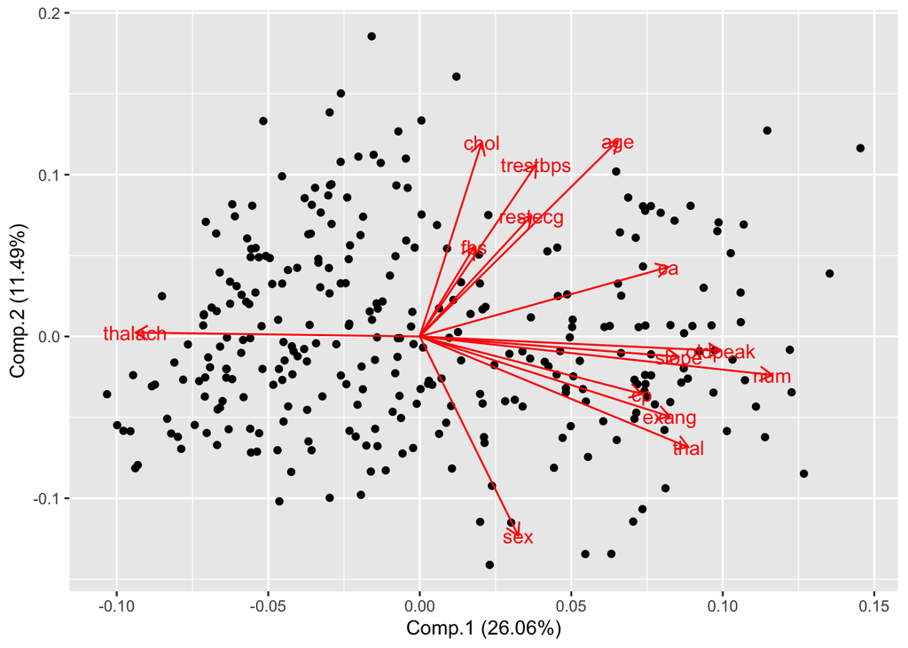

This plot shows all variables plotted at once. The arrows show which direction each variable influences each point. However, the plot is confusing and only accounts for 37.55% of variability of the data.

Instead, we can separate variables into 4 distinct groupings:

| Group 1 | Group 2 | Group 3 | Group 4 |
| --- | --- | --- | --- |
| cp | age | sex | slope |
| num | trestbps | thal | oldpeak |
| exang | fbs |  |  |
| -thalach | ca |  |  |

G1: chest pain, heart disease severity, exercise induced angina, max heart rate

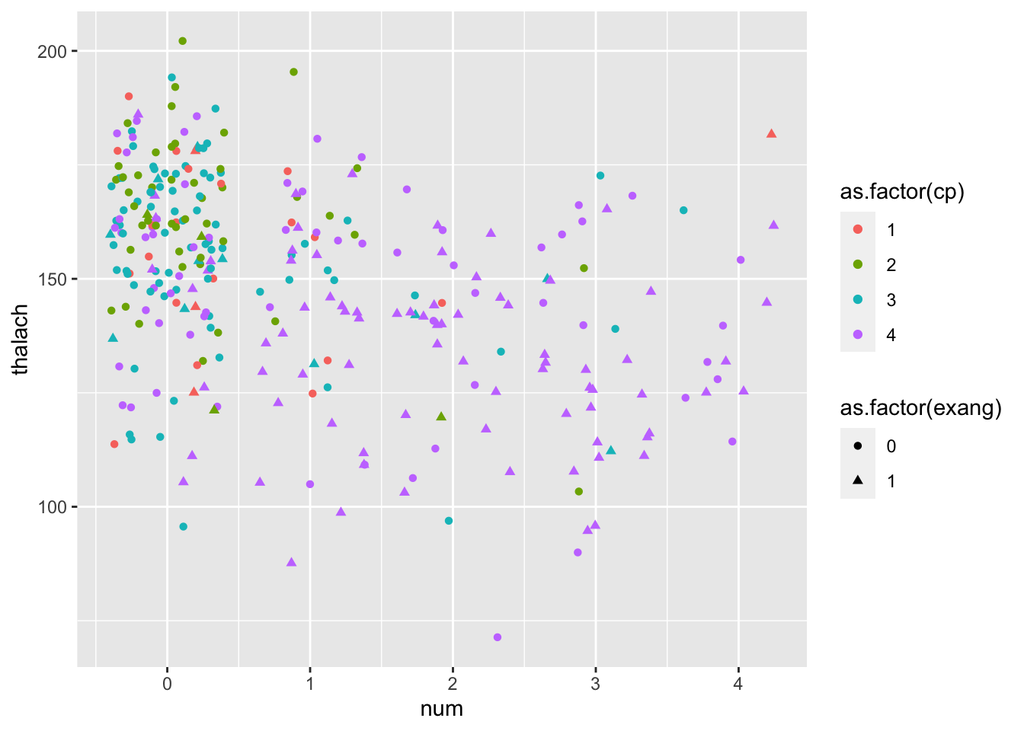

G2: age, blood pressure, high blood sugar, vessels colored by floursopy

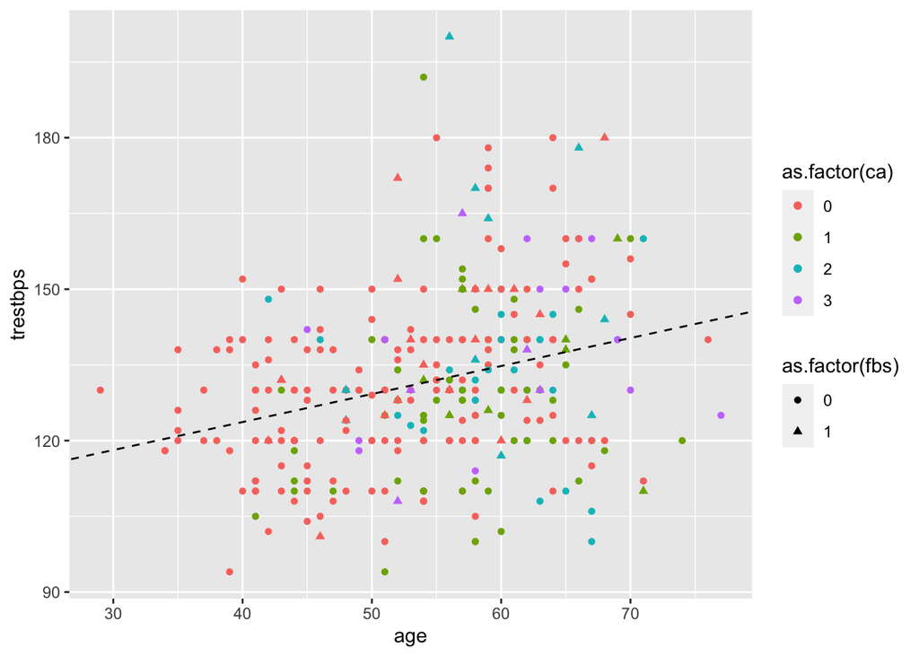

G3: sex, defects

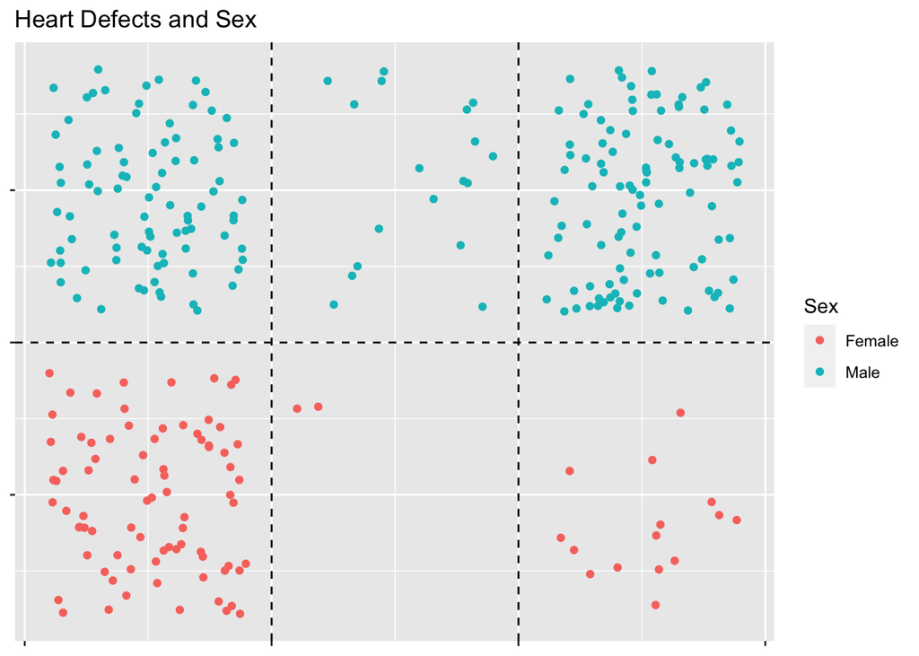

The 3 columns represent no heart defect, a fixed heart defect, and a reversible heart defect. This data shows that men are more likely to have a heart defect, as well as more likely for said heart defect to be fixed.

G4: slope of ST, ST depression from exercise

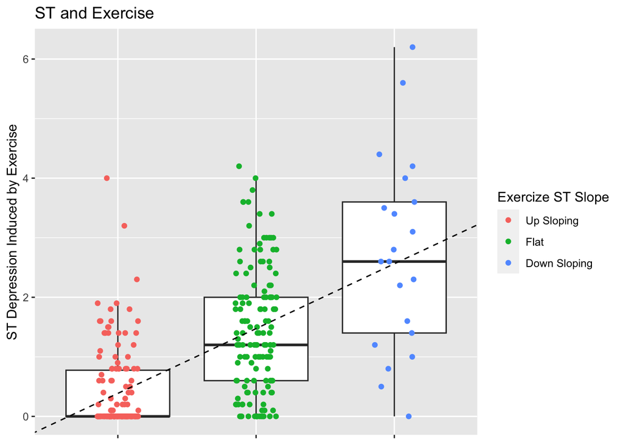

The conclusion we can draw from this group is that those who already have a down sloping ST at peak exercise are more likely to have said ST slope more negatively affected by exercise than those with a up sloping or flat ST. Also note that those with upsloping ST seem to have more outliers than the rest.